# Genetic status across the conservation-genomics toolkit: GBF indicators, contemporary N_e, and genetic load — and how fragile each verdict is to analyst choices

Author

andakprapakorn

Published

July 19, 2026

# 1 Introduction

Two chapters exercise the modern conservation-genomics toolkit on public whole-genome data: (1) the new Global Biodiversity Framework (GBF) genetic-diversity indicators applied to the endangered green peafowl (*Pavo muticus*), and (2) realized-versus-masked genetic load in the inbred Scandinavian wolf (*Canis lupus*). The cross-cutting question is not “what is the number?” but **“how fragile is the verdict to defensible analyst choices?”** — filtering stringency, whether population structure is modelled, the GERP threshold that defines an operational predicted-impact site class, and the run-of-homozygosity length used as an autozygosity proxy. Where a headline moves under choices a competent analyst could each justify, we report the movement itself as the result.

The GBF adopted a genetic-diversity target — the proportion of populations with effective size $N_e > 500$ (Hoban et al. 2020; Mastretta-Yanes et al. 2024) — that is now being operationalized by national reporters. A central practical question is how stable that indicator is when computed from real, small-sample data. The wolf chapter provides a contrasting, data-rich case where the source study (Smeds et al. 2023) published a per-individual load table we can reproduce exactly, letting us separate genuine signal from analyst sensitivity.

**Phase 5B status: COMPLETE.** This Quarto source does not recompute the Phase-5B analyses: `load_report_values()` validates and reads the generated workflow tables and six-row claim trace, and the render stops if a required output or column is absent. The frozen outcomes are **15/15**, **1/4**, **0/15**, **IMPLEMENT**, **24/24**, and **DEFER_DUPLICATES_SOURCE_STUDY**; the sections below preserve the uncertainty and scientific boundary attached to each value. Two isolated clean-science builds, final-source reconciliation, bounded-memory evidence, matching hashes/manifests, and no-op verification are recorded in the Phase-5B reproducibility record.

# 2 Methods

## 2.1 Data

- **Green peafowl** — Dong et al. (2021), Dryad `10.5061/dryad.ffbg79ctc`. Modern resequencing across three regional populations plus six museum specimens. After a kinship screen (below) the analysis set is **22 unrelated individuals** across **Yunnan (n = 7), Vietnam (n = 10), Thailand (n = 5)**; Cambodia (n = 1) is dropped. A separate, geographically mismatched museum-versus-modern comparative callset supports a period-labelled sample contrast (5 museum and 6 modern individuals after comparative-sample QC), not an estimate of temporal genetic erosion because period and geography are not separated by design.
- **Scandinavian wolf** — Smeds et al. (2023), Dryad `10.5061/dryad.7m0cfxpzj`. 211 individuals with ancestral-allele-polarized SNPs (`INFO/AA`, two outgroups), VEP/SIFT coding annotation, and per-site GERP conservation scores. Individuals carry a time-period label (founding cohort ~1983 through 2007–2014) plus outbred references (Finland, Russia, immigrants).

All empirical genomic analyses start from the deposited VCFs (no re-calling from reads). The country-level Populations Maintained indicator starts from a versioned curated table, and the design calibration adds transparent bounded neutral simulations. Every threshold lives in `config/config.yaml`, and the fragility axes *are* that config made executable.

## 2.2 QC and filtering (peafowl)

Two callsets are derived from a shared normalized parent (`bcftools norm -m -any`, biallelic SNPs on the 32 autosomes): **unpruned Set A** (neutral) feeds currentNe2, while an **LD-pruned derivative of Set A** feeds the structure analyses; **Set B** (lightly filtered, no MAF/MAC/HWE/LD-prune) feeds diversity and preserves rare alleles. The *filtering-stringency* knob re-derives Set A per preset — **lenient / standard / strict** (max-missing 0.7/0.8/0.9, min-GQ 15/20/30, min-DP 4/6/8, MAC 3) — yielding **1,046,916 / 420,826 / 30,143** post-MAC sites (a ~35× spread). Per-population HWE ($P < 10^{-6}$ in any population) is applied to avoid Wahlund false departures. A confirmatory KING kinship screen retains all 22 individuals.

## 2.3 Contemporary $N_e$ and the fragility cube (peafowl)

The parameter sweep is `{filter} × {structure}` → `results/cube/results_cube.parquet`, with **currentNe2** as the sole automated estimator. LD-based $N_e$ estimators read $N_e$ *out of* linkage disequilibrium, so the un-pruned Set A is fed with a genome size of 32 Morgans (the autosome count), invoking currentNe2’s cross-chromosome (“no genetic map needed”) mode (Santiago et al. 2024); LD-pruning would destroy the very signal being measured. The *structure* knob contrasts **modelled** (`per_population`, the three values feeding the GBF fraction) with **ignored** (`pooled`, all 22 lumped — a Wahlund-biased cautionary contrast). NeEstimator-LDNe is a manual field-standard comparison planned outside the DAG but **not run**; **GONE2** provides a recent-trajectory *context* panel only (a borrowed avian recombination rate, macrochromosomes only), never the contemporary indicator (Waples 2024).

## 2.4 GBF indicators (peafowl)

From the cube we compute the **$N_e > 500$ indicator** (proportion of per-population estimates above threshold, per preset) and a **robustness** table (verdict stability across presets). The complementary **Populations Maintained (PM)** indicator is non-genomic, curated from IUCN/BirdLife range records at country resolution; a census $N_c$ proxy contrast uses a conservative vertebrate $N_e{:}N_c = 0.1$ (Frankham 1995). The three-state verdict — pass / fail / **indeterminate** (CI straddles 500, or no convergence) — is precomputed in the workflow.

## 2.5 Genetic load and ROH (wolf)

Per-individual load faithfully re-implements Smeds et al. (2023)’s `gerp_load_polarized.py`. For each SNP the derived allele is the non-ancestral allele (`INFO/AA`); a site enters the operational **GERP-defined predicted-impact class** at threshold $t$ if its GERP RS score $> t$. Per individual we accumulate, in a single per-chromosome VCF stream, GERP-weighted **realized** load ($\sum 2g$ over homozygous-derived sites in that class $/$ calls) and **masked** load ($\sum g$ over heterozygous sites in that class $/$ calls), summing raw counts across chromosomes. We extend the source method by sweeping the GERP threshold over **{2, 3, 4}** in one pass — the wolf-side fragility knob — while GERP > 4 reproduces the deposit’s precomputed table exactly (Results). Runs of homozygosity are called with `bcftools roh` (GT-based HMM, a documented constant recombination rate) and summarized as per-individual $F_{ROH}$ swept over a ROH-length cutoff, with long ROH ($\geq 1.5$ Mb) used as a proxy for more recent autozygosity (Bertorelle et al. 2022).

## 2.6 Phase-5B falsification and decision analyses

The extension was executed in a fixed order, with each independent validator acting as the next analysis gate. For the museum–modern comparison, all-SNP estimates were paired with **transversion-only** estimates; all $\binom{11}{5}=462$ museum-label allocations were evaluated; six equal-$n$ modern omissions and all 11 leave-one-individual cases were retained; and uncertainty came from 999 seeded 5-Mb chromosome-block resamples. Raw-comparative genomic opportunity remains the denominator for $\pi$, while normalized complete-call autosomal SNPs remain the basis for $H_o$, $H_e$, and analytically rarefied allelic richness. These checks can reduce a damage concern; they cannot separate collection period from the deposited groups’ geographic mismatch.

For the $N_e$ design analysis, neutral monoecious diploid ideal Wright–Fisher scenarios used a shared-parent pedigree. Each offspring gamete selected one parent genome-wide; Mendelian inheritance with Haldane recombination then operated along 32 one-Morgan chromosomes for 15 generations. Loci were initialized in Hardy–Weinberg equilibrium, retained only when polymorphic in the smallest nested sample ($n=5$), and reused in nested individual panels of 5/10/15/20/30 and balanced nested marker panels of 250/500/1,000 for known $N_e=100/250/500/1{,}000$. Free assortment makes cross-chromosome disequilibrium approach its drift equilibrium rapidly, which is why the cross-chromosome currentNe2 estimate is the prespecified headline; 15 generations do not guarantee within-chromosome drift–recombination equilibrium. Every attempt—including timeout, parse failure, or non-convergence—passed through the same currentNe2 binary, 90% interval parser, and decision rule as the empirical cube. The seeded pilot was repeated identically before bounded expansion.

Empirical individual/marker downsampling stayed within each real population’s observed sample size and has **unknown truth**; it is never scored correct or incorrect. Scenario Wilson intervals quantify Monte-Carlo uncertainty across simulated replicates. At the observed empirical $n$, repetitions necessarily reuse the single available individual subset, and lower-$n$ subsets overlap; empirical Wilson bands therefore summarize seeded subset/marker-panel sensitivity, not independent biological-sampling uncertainty. The scenarios calibrate this estimator/decision pipeline, not peafowl history or a promise that an exact real sample size will resolve the indicator.

For wolves, all 211 load/ROH records were joined across the frozen 3 GERP $\times$ 5 ROH grid. Within-cohort fractional ranks were associated with realized and masked load; cohort-stratified bootstrap intervals and within-cohort permutations preserve the grouping structure. A partial model controls the within-cohort rank of generic GERP-covered genotype homozygosity, providing a predeclared mathematical-coupling check. Individual risk-proxy ranking uses the mean of $F_{ROH}$ rank, realized-load rank, and inverse masked-load rank. These remain associations among genomic proxies, not genotype–fitness or causal inbreeding-depression estimates.

After the predeclared negative-control gate opened, ROH localization streamed the indexed wolf VCF one chromosome at a time. For every individual and frozen GERP/ROH cell, homozygous-derived GERP-weighted burden was partitioned inside versus outside the individual’s ROH intervals and divided by eligible polarized GERP-threshold SNP genotype calls. The partitions reconcile to Phase 4, and ROH interval unions reconcile to $F_{ROH}$. Each of 199 seeded null replicates circularly shifts an individual’s complete set of intervals within the same chromosome, preserving chromosome and interval lengths while sampling the fixed eligible-SNP-genotype and burden landscapes. Cohort enrichment is compared with that position null. This tests genomic co-localization, not organismal harm or causation.

# 3 Results

## 3.1 Peafowl: diversity, structure, and temporal contrast

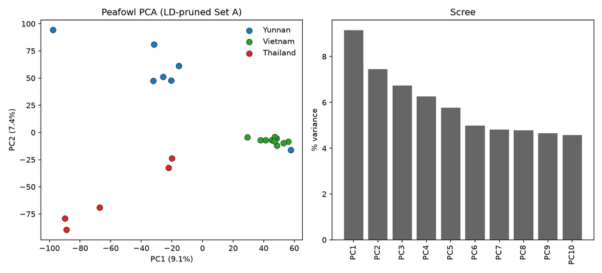

Figure 1: Peafowl population structure on the first two PCA axes, computed from the LD-pruned derivative of Set A. Separation supports population-aware analysis, while low per-axis variance and small sample sizes limit how strongly the geometry should be interpreted.

## 3.2 Peafowl: damage-aware falsification

The weak temporal contrast does **not** become a temporal-erosion claim. Only 1/4 metrics retain a museum-higher direction through every predeclared damage and individual-influence check, and exact-label p-values span 0.331–0.831. Transversion filtering retains the sign of each metric, but $H_e$ and allelic richness are modern-higher; $H_o$ is also single-individual-sensitive. The 5-Mb block intervals show the effect sizes rather than reducing the result to significance labels. Most importantly, the source groups still differ in geography as well as collection period. The defensible conclusion remains a **sample contrast with mixed metric directions**, not temporal genetic erosion.

Table 1: Museum-minus-modern effects under all-SNP and transversion-only definitions.

|  | variant_set | metric | effect_museum_minus_modern | ci_low | ci_high | exact_permutation_p_two_sided | direction |
| --- | --- | --- | --- | --- | --- | --- | --- |
| 0 | all_snp | He | -0.010904 | -0.012806 | -0.009048 | 0.331169 | modern_higher |
| 4 | transversion_only | He | -0.010964 | -0.013263 | -0.008706 | 0.370130 | modern_higher |
| 1 | all_snp | Ho | 0.020821 | 0.013261 | 0.028663 | 0.673160 | museum_higher |
| 5 | transversion_only | Ho | 0.020991 | 0.012886 | 0.029229 | 0.666667 | museum_higher |
| 2 | all_snp | allelic_richness | -0.004757 | -0.006699 | -0.002883 | 0.402597 | modern_higher |
| 6 | transversion_only | allelic_richness | -0.005137 | -0.007343 | -0.002893 | 0.367965 | modern_higher |
| 3 | all_snp | pi | 0.000007 | 0.000005 | 0.000009 | 0.816017 | museum_higher |
| 7 | transversion_only | pi | 0.000002 | 0.000001 | 0.000002 | 0.831169 | museum_higher |

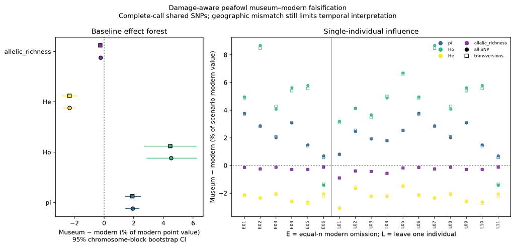

Figure 2: Damage-aware museum–modern effect intervals and individual-influence diagnostics. All effects are shown, including modern-higher and individually fragile results; the geographic mismatch remains a design limit under every row.

## 3.3 Peafowl: contemporary $N_e$ and the fragility of the GBF verdict

**No population confidently passes $N_e > 500$ under any filtering preset** (0/3 / 0/3 / 0/3 pass for lenient / standard / strict). Verdicts are *fail* (point and 90% CI below 500) or *indeterminate*. Under the lenient preset the cross-chromosome estimates are Yunnan 55 [20–152], Thailand 76 [18–320], and Vietnam 2,293 [139–37,795] — the lone point above 500, but with a CI straddling it, hence *indeterminate*, not a pass. Under stricter presets several per-population estimates fail to converge (extreme heterozygote excess at small $n$), so convergence itself is preset-fragile (Table: `results/tables/gbf_robustness.tsv`). Pooling across populations (structure ignored) trends low and rises with stringency (52 → 89 → 108), below most per-population estimates — the predicted Wahlund direction, muddied by small-$n$ noise.

The result is therefore two-sided: the **headline is robust** (0/3 pass regardless of preset), while the **underlying estimates are fragile** (2/3 populations change verdict across presets; Vietnam is estimable under lenient but not under stricter filters). The GONE2 context trajectory shows a recent decline (approximately 3,577 → 176 over ~416 generations), consistent with an endangered species but presented as context only.

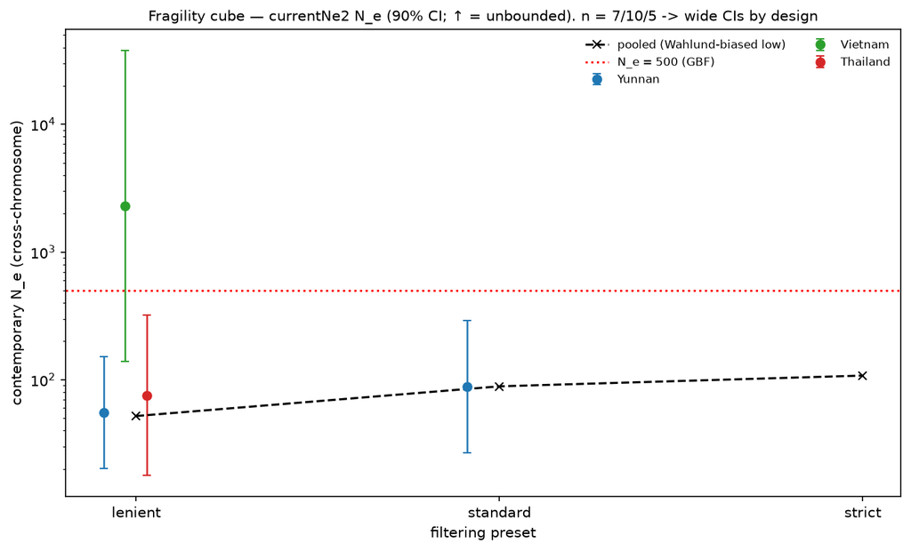

Figure 3: Contemporary peafowl effective-size estimates across filtering presets and population-structure treatments. The horizontal threshold marks $N_e=500$; wide intervals and non-converged cells show why the estimate magnitudes are fragile even though the no-confident-pass headline is stable. Only the per-population cells feed the GBF indicator.

## 3.4 Peafowl: $N_e$ sample-design calibration

0/15 simulated sample-size/marker designs meet the predeclared two-sided decision-resolution rule; empirical downsampling is reported separately. The frozen result is **0/15** simulated sample-size/marker designs resolving both predeclared resolution truths ($N_e=250$ and $N_e=1{,}000$) under the predeclared two-sided rule; the corresponding compact design reading is **no qualifying simulated design**. Correct-confident, incorrect-confident, indeterminate, and execution-failure rates remain separate, with 95% Wilson intervals shown in the machine table. True $N_e=500$ is treated as a boundary and is never scored as correct or incorrect. The empirical panel is deliberately labelled sensitivity rather than validation because the true $N_e$ of those downsampled birds is unknown, the observed-$n$ repetitions reuse individuals, and lower-$n$ subsets overlap. No tested configuration therefore supports an exact sample-size prescription: the neutral scenarios calibrate this estimator/decision pipeline and are not a guarantee for a future real peafowl collection.

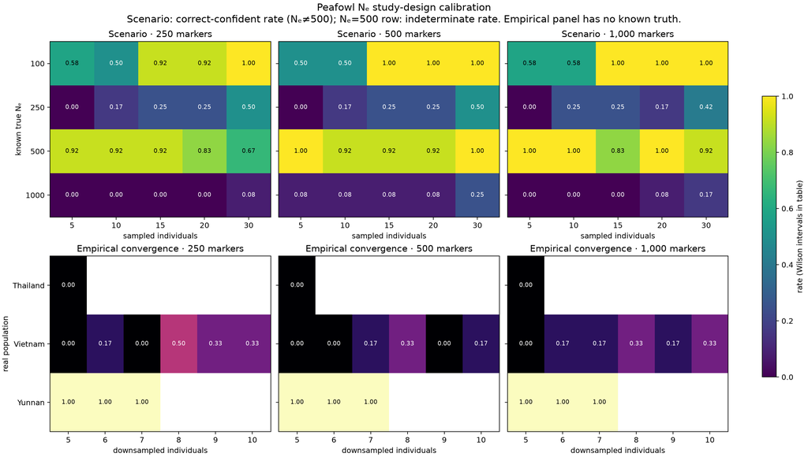

Figure 4: Known-truth neutral scenario resolution by sampled individuals and marker density (top), separated from observed-range empirical convergence (bottom). The empirical panel has no correctness score.

## 3.5 Peafowl: the two GBF indicators give contrasting, non-equivalent readings

The genomic indicator gives **0/3 sampled populations confidently classified above $N_e>500$**, whereas **Populations Maintained = 0.70 (7/10 range units maintained; no unresolved swing cases)**. All three sampled populations lie within the “maintained” set — yet none is confidently classified above the threshold. Range-wide census (~10,000–19,999 mature, EN) nominally clears the $N_c \geq 5\,000$ proxy, but that is the wrong denominator for a *per-population* indicator: no matched population-level census denominator is available for the three sampled cells, and fragmentation prevents translating a range-wide total into one. **Still present ≠ confidence that a genomic proxy clears its threshold** — the two Goal-A indicators answer different questions and must be reported together.

## 3.6 Wolf: exact reproduction, then the fragility axes

At **GERP > 4 the per-individual realized and masked loads reproduce the deposit’s precomputed `LoadPerInd.thres4` table exactly** — 95th-percentile relative error 1.3e-14 and raw count deltas of 0/0/0 across all 211 individuals — confirming the re-implementation is faithful before any extension. The biological signal is recovered correctly: the inbred **Scandinavian** cohorts carry **realized > masked** load (0.091–0.105 realized versus 0.052–0.079 masked), whereas outbred references (**Finland, Russia, immigrants**) carry **masked > realized** (0.100–0.101 masked versus 0.085–0.089 realized) — the masked-to-realized group pattern reported by the source study and consistent with recessive-load exposure (Smeds et al. 2023; Bertorelle et al. 2022). This reanalysis does not by itself identify a causal conversion.

Both knobs move magnitude but not the pattern. Mean realized load falls 0.172 → 0.136 → 0.093 across GERP 2/3/4 (a stricter conservation filter keeps fewer, higher-confidence sites), and mean $F_{ROH}$ falls 0.226 → 0.167 as the ROH-length cutoff rises 0.1 → 2 Mb (shifting the long-ROH autozygosity proxy away from shorter background homozygosity). The realized-versus-masked *direction* is robust to the GERP threshold — the wolf-side counterpart to the peafowl fragility finding: the number depends on the choice, the signal does not.

## 3.7 Wolf: individual-level association and negative control

The frozen claim-trace outcome is **15/15 primary and 15/15 partial realized-load intervals above zero**. The primary within-cohort rank association between $F_{ROH}$ and realized load is 0.879–0.928 across the 15 cells. After controlling generic GERP-covered homozygosity it remains 0.721–0.820, with 15/15 cohort-bootstrap intervals entirely above zero. The analogous partial masked-load association has 0/15 intervals excluding zero. Risk-proxy rankings are stable across the grid (Spearman 0.992–0.999; minimum tested top-set overlap 90.9%). The negative control therefore supports proceeding to the predeclared ROH-localization test, but it does not turn proxy covariation into a fitness or causal claim.

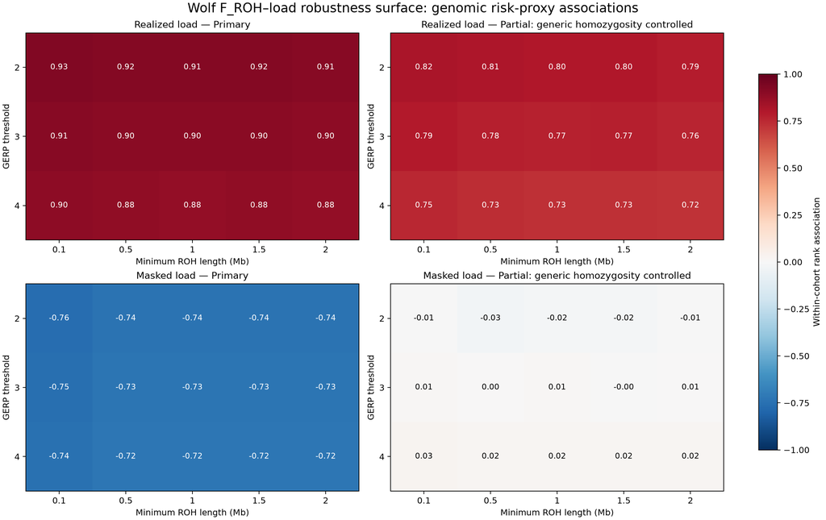

Figure 5: Within-cohort F_ROH–load associations across every GERP and ROH cutoff, before and after the generic-homozygosity control.

## 3.8 Wolf: ROH-localized realized burden

At the predeclared 1.5 Mb cutoff, observed realized-burden enrichment exceeds the circular-shift null upper bound with two-sided permutation p <= 0.05 in 24/24 population-by-GERP cells. The frozen long-ROH result is **24/24** population-by-GERP cells beyond the null (**GERP > 2: 8/8; GERP > 3: 8/8; GERP > 4: 8/8**). At the predeclared 1.5-Mb long-ROH cutoff, observed log2 inside/outside burden-per-eligible-genotype-call ratios span 0.922–1.265; the exact cell-wise support count is 24/24 (GERP>2: 8/8, GERP>3: 8/8, GERP>4: 8/8). A cell is beyond-null only when its observed enrichment exceeds the 97.5th percentile of 199 within-chromosome circular ROH shifts **and** its plus-one two-sided permutation p-value is at most 0.05. Every population, GERP threshold, and ROH cutoff remains in the machine tables regardless of direction or p-value.

Inside plus outside burden, derived copies, and eligible genotype-call opportunity reconcile to the validated Phase-4 genome-wide totals; independently rebuilt ROH unions reconcile to $F_{ROH}$. One denominator unit is a nonmissing diploid genotype at a variant-only allSNPs record with an exact GERP key, valid ancestral-allele polarization, and score strictly above the selected threshold. It is an assayed-SNP opportunity denominator, not callable genomic bases; circular shifts preserve the observed SNP/GERP landscape but cannot remove every ascertainment effect. This is localization of one genomic risk proxy within another and therefore mechanistic support only—not measured individual harm, fitness, causal inbreeding depression, or a management-unit result.

Table 2: Cohort ROH-localization results at the predeclared 1.5-Mb cutoff.

|  | POP | gerp_threshold | n_ind | inside_eligible_genotype_calls | outside_eligible_genotype_calls | log2_enrichment | null_ci_low | null_ci_high | permutation_p_two_sided | beyond_null |
| --- | --- | --- | --- | --- | --- | --- | --- | --- | --- | --- |
| 24 | 1983-1990 | 2 | 14 | 3124291 | 9721143 | 0.921987 | 0.340584 | 0.401256 | 0.005 | True |
| 25 | 1991-1998 | 2 | 16 | 3011373 | 11787205 | 0.931201 | 0.270091 | 0.343328 | 0.005 | True |
| 26 | 1999-2006 | 2 | 24 | 7951101 | 13147176 | 0.966547 | 0.325814 | 0.370132 | 0.005 | True |
| 27 | 2007-2014I | 2 | 16 | 2547220 | 11066663 | 1.025959 | 0.288656 | 0.361984 | 0.005 | True |
| 28 | 2007-2014S | 2 | 21 | 6176898 | 9457109 | 0.981855 | 0.274346 | 0.329526 | 0.005 | True |
| 29 | Finland | 2 | 95 | 6866668 | 81223555 | 1.243134 | 0.325373 | 0.370850 | 0.005 | True |
| 30 | Immigrants | 2 | 11 | 684880 | 8999973 | 1.176586 | 0.223382 | 0.350479 | 0.005 | True |
| 31 | Russia | 2 | 14 | 810503 | 12234672 | 1.234340 | 0.177592 | 0.315340 | 0.005 | True |
| 64 | 1983-1990 | 3 | 14 | 2124246 | 6562911 | 0.922747 | 0.339135 | 0.401251 | 0.005 | True |
| 65 | 1991-1998 | 3 | 16 | 2069841 | 7940684 | 0.925051 | 0.266278 | 0.336910 | 0.005 | True |
| 66 | 1999-2006 | 3 | 24 | 5495255 | 8768206 | 0.954798 | 0.315436 | 0.361529 | 0.005 | True |
| 67 | 2007-2014I | 3 | 16 | 1724525 | 7483620 | 1.029980 | 0.292721 | 0.363240 | 0.005 | True |
| 68 | 2007-2014S | 3 | 21 | 4166298 | 6392257 | 0.985925 | 0.273653 | 0.330450 | 0.005 | True |
| 69 | Finland | 3 | 95 | 4632427 | 54959442 | 1.250608 | 0.323487 | 0.368715 | 0.005 | True |
| 70 | Immigrants | 3 | 11 | 450848 | 6098868 | 1.196517 | 0.226059 | 0.359132 | 0.005 | True |
| 71 | Russia | 3 | 14 | 546585 | 8277279 | 1.240606 | 0.181274 | 0.317216 | 0.005 | True |
| 104 | 1983-1990 | 4 | 14 | 1271723 | 3916148 | 0.927473 | 0.338495 | 0.401426 | 0.005 | True |
| 105 | 1991-1998 | 4 | 16 | 1247051 | 4732051 | 0.927914 | 0.265570 | 0.338029 | 0.005 | True |
| 106 | 1999-2006 | 4 | 24 | 3324837 | 5193427 | 0.952897 | 0.313583 | 0.362166 | 0.005 | True |
| 107 | 2007-2014I | 4 | 16 | 1027094 | 4476524 | 1.037003 | 0.294067 | 0.369501 | 0.005 | True |
| 108 | 2007-2014S | 4 | 21 | 2483053 | 3823234 | 0.988588 | 0.271756 | 0.328558 | 0.005 | True |
| 109 | Finland | 4 | 95 | 2761197 | 32835499 | 1.265323 | 0.323033 | 0.371514 | 0.005 | True |
| 110 | Immigrants | 4 | 11 | 265127 | 3647781 | 1.208233 | 0.232021 | 0.371247 | 0.005 | True |
| 111 | Russia | 4 | 14 | 323768 | 4946137 | 1.253666 | 0.183151 | 0.322190 | 0.005 | True |

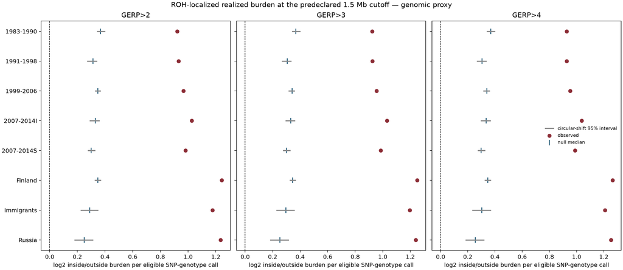

Figure 6: Observed ROH-localized burden at 1.5 Mb, with circular-shift null medians and intervals for every cohort and GERP threshold.

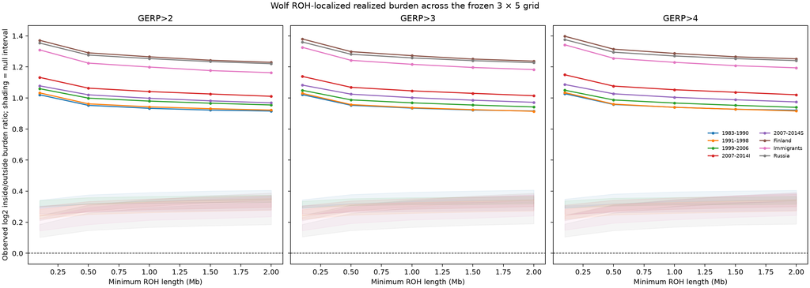

Figure 7: ROH-localized burden across the complete frozen three-GERP by five-ROH-cutoff grid; ribbons are circular-shift null intervals, not fitness-effect intervals.

## 3.9 Optional-study decisions

Section 13.4 is **IMPLEMENT**—the validated **IMPLEMENT** decision: 15/15 partial coefficients positive; 15/15 have CI low > 0. Section 13.5 is **DEFER_DUPLICATES_SOURCE_STUDY**—the validated **DEFER_DUPLICATES_SOURCE_STUDY** decision: Local autosomal VEP/SIFT class counts exactly match the source analysis; common sample intersection is 211/211. The source already compares VEP/SIFT, genome-wide GERP, and their source-labeled SIFT-‘deleterious’ intersection.. The latter records **0/1 independent annotation definitions** and **211/211 common samples**, avoiding presentation of the source study’s own VEP/SIFT/GERP comparison as independent triangulation. It reopens only with at least one annotation definition independent of the deposited source classes, at least 0.95 common-sample coverage, and at least 0.90 auditable callable-denominator coverage. Predicted-impact classes remain risk proxies, not proven harmful variants. Both decisions and their numeric reopening conditions are machine-readable and independently validated in `results/tables/phase5b_optional_decisions.tsv`.

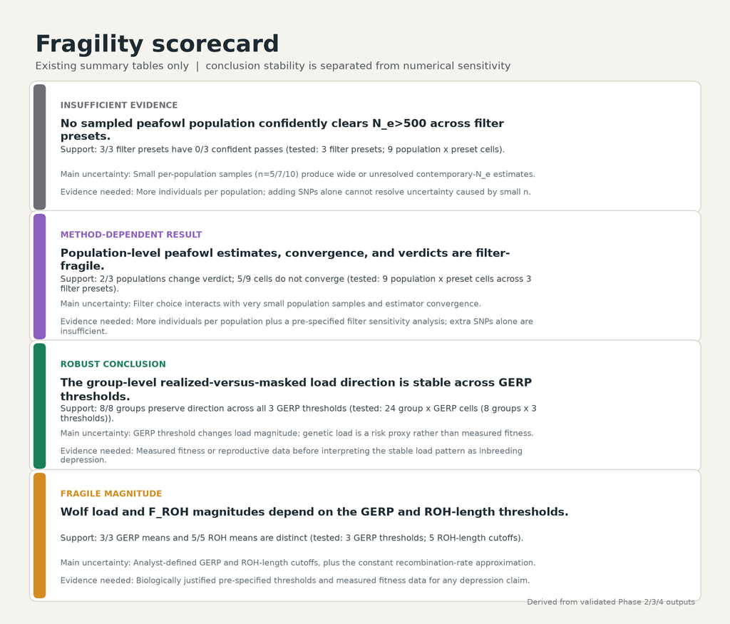

Figure 8: Cross-chapter fragility scorecard computed from the existing peafowl cube, GBF tables, wolf-load table, and wolf-ROH table. Categories summarize stability under the settings tested here; they are not claims of universal robustness beyond these data and methods.

# 4 Limitations

We claim **risk, not demonstrated inbreeding depression**. For the peafowl, small per-population $n$ (7/10/5) yields wide $N_e$ CIs and many *indeterminate* verdicts by construction; the estimates should not be cited as point values, and the temporal contrast is geographically narrow and aDNA-sensitive. Both empirical chapters are **reanalyses of published data**, so the peafowl conclusion (none of the three sampled populations is confidently classified above $N_e>500$ under the tested cells) is a bounded indicator result rather than proof of genetic erosion, and the wolf load reproduces a published result. The genuine contribution is methodological: a quantified demonstration that a live policy indicator (the GBF $N_e > 500$ verdict) and a load estimate are sensitive to defensible analyst choices, with the two non-equivalent GBF indicators shown to give contrasting readings for the same species. GONE2 (borrowed rate) and the ROH recombination rate (no dense wolf map) are documented approximations. The fragility cube quantifies, rather than hides, this uncertainty.

Phase 5B does not remove the source designs’ boundaries. Transversion filtering reduces one ancient- DNA concern but cannot remove all museum-specific technical bias or the time–geography confounding. The neutral $N_e$ scenarios use an idealized 32-chromosome pedigree with explicit linkage and recombination, but simplify chromosome lengths, recombination architecture, and population history and omit mutation, selection, migration, population structure, and demographic change; their known-truth rates calibrate the implemented decision rule only. The wolf partial analysis controls one generic-homozygosity proxy, not every possible shared denominator or cohort process. The ROH-localization null preserves each interval’s chromosome and length through circular shifts, but it is still a genomic position null rather than an experiment or genotype–fitness design. All Monte-Carlo failures and indeterminate outcomes remain in their denominators.

# 5 What evidence would change the conclusion?

The limitations above are decision points, not promises to collect more data. This evidence map identifies the next evidence or predeclared decision rule for each unresolved inference; none is required to reproduce the present analysis.

[output not shown]

# 6 Reproducibility statement

All analytical results are built by the Snakemake DAG from tracked inputs: two public deposits, the versioned curated Populations Maintained table, and transparent bounded neutral simulations. The Streamlit explorer reads the outputs only. The clean verification record preserves two isolated clean-science builds and their resource measurements, six matching science hashes, two exact input-manifest aggregates, final-source reconciliation, and final-topology no-op results.

The report performs a render-time schema check and reads its headline analytical values from the following workflow outputs. Missing files or columns stop the render rather than preserving stale prose.

Table 3: Workflow outputs loaded by the report at render time.

|  | Result block | Workflow output |
| --- | --- | --- |
| 0 | Filtering counts | results/tables/qc_snp_counts.tsv |
| 1 | Structure | results/tables/pca_coords.tsv |
| 2 | PCA variance | results/tables/pca_variance.tsv |
| 3 | ADMIXTURE CV | results/tables/admixture_cv.tsv |
| 4 | Modern diversity | results/tables/diversity_perpop.tsv |
| 5 | Allelic richness | results/tables/allelic_richness_modern.tsv |
| 6 | Temporal diversity | results/tables/temporal_diversity.tsv |
| 7 | Temporal pi | results/tables/temporal_pi_summary.tsv |
| 8 | Temporal allelic richness | results/tables/temporal_allelic_richness.tsv |
| 9 | Effective-size cube | results/cube/results_cube.csv |
| 10 | GBF Ne indicator | results/tables/gbf_ne500.tsv |
| 11 | GBF robustness | results/tables/gbf_robustness.tsv |
| 12 | Populations Maintained | results/tables/gbf_populations_maintained.tsv |
| 13 | GBF summary | results/tables/gbf_summary.tsv |
| 14 | GONE2 context | results/tables/gone2_trajectory.tsv |
| 15 | Wolf load | results/tables/wolf_load.tsv |
| 16 | Wolf ROH | results/tables/wolf_roh.tsv |
| 17 | Wolf validation | results/tables/validation_phase4.tsv |
| 18 | Fragility scorecard | results/tables/fragility_scorecard.tsv |
| 19 | Wolf individual association | results/tables/wolf_froh_load_associations.tsv |
| 20 | Wolf rank stability | results/tables/wolf_froh_load_rank_stability.tsv |
| 21 | Damage-aware effects | results/tables/peafowl_damage_effects.tsv |
| 22 | Ne design summary | results/tables/peafowl_ne_design_summary.tsv |
| 23 | Wolf ROH localization | results/tables/wolf_roh_localization_cohort.tsv |
| 24 | Wolf ROH localization validation | results/tables/validation_wolf_roh_localizatio... |
| 25 | Phase 5B decisions | results/tables/phase5b_optional_decisions.tsv |
| 26 | Phase 5B claim trace | results/tables/phase5b_claim_trace.tsv |

```bash
CONDA_SUBDIR=osx-64 micromamba create -n congen -f environment.lock.yml  # Apple Silicon/Rosetta
micromamba activate congen && conda config --env --set subdir osx-64
scripts/build_tools.sh                                 # currentNe2 + GONE2, pinned commits
scripts/fetch_data.sh && scripts/extract_data.sh       # Dryad data
snakemake --snakefile workflow/Snakefile phase5b --cores 4 --resources mem_mb=7000  # phases 1-5B
report/render_report.sh                                # schema-check values and render report/report.html
streamlit run app/streamlit_app.py                     # the live fragility explorer
```

Every threshold and parameter lives in `config/config.yaml`; per-phase and Phase-5B analysis gates assert the outputs are well-formed, preserve failures/null outcomes, and reconcile figure bridges and provenance hashes. For wolf load, the Phase-4 gate also reconciles against the deposit’s own numbers. R packages ship with the conda environment (R is conda-owned; no `renv.lock`).

# 7 References

Bertorelle, Giorgio et al. 2022. “Genetic Load: Genomic Estimates and Applications in Non-Model Animals.” *Nature Reviews Genetics* 23: 492–503. https://doi.org/10.1038/s41576-022-00448-x.

Dong, Feng et al. 2021. “Population Genomic, Climatic and Anthropogenic Evidence Suggest the Role of Human Forces in Endangerment of Green Peafowl (Pavo muticus).” *Proceedings of the Royal Society B: Biological Sciences* 288 (1948): 20210073. https://doi.org/10.1098/rspb.2021.0073.

Frankham, Richard. 1995. “Effective Population Size/Adult Population Size Ratios in Wildlife: A Review.” *Genetical Research* 66 (2): 95–107. https://doi.org/10.1017/S0016672300034455.

Hoban, Sean et al. 2020. “Genetic Diversity Targets and Indicators in the CBD Post-2020 Global Biodiversity Framework Must Be Improved.” *Biological Conservation* 248: 108654. https://doi.org/10.1016/j.biocon.2020.108654.

Mastretta-Yanes, Alicia et al. 2024. “Multinational Evaluation of Genetic Diversity Indicators for the Kunming-Montreal Global Biodiversity Framework.” *Ecology Letters* 27 (7): e14461. https://doi.org/10.1111/ele.14461.

Santiago, Enrique et al. 2024. “Estimation of the Contemporary Effective Population Size from SNP Data While Accounting for Mating Structure.” *Molecular Ecology Resources* 24 (1): e13890. https://doi.org/10.1111/1755-0998.13890.

Smeds, Linnéa et al. 2023. “From High Masked to High Realized Genetic Load in Inbred Scandinavian Wolves.” *Molecular Ecology* 32 (7): 1567–80. https://doi.org/10.1111/mec.16802.

Waples, Robin S. 2024. “Practical Application and Interpretation of the Linkage-Disequilibrium Method for Estimating Contemporary Effective Population Size.” *Molecular Ecology Resources* 24 (1): e13879. https://doi.org/10.1111/1755-0998.13879.